# rstudioexam

**Exam 1 Take Home Portion**

**INSTRUCTIONS**

- This exam is an individual exam.
- This exam is “open-book, open-note, open-Google”.
- Do not consult with other students.
- Submit your work on Canvas as a **rendered HTML file**.
- Late submissions will NOT be accepted without prior approval.
- Be sure that your answers are easy to identify.
- You may use the “esquisse” package for developing plots (if desired)

Run the lines of code below to read in a dataset containing historical Major League Baseball team performance data.

```r
url = "https://www.dropbox.com/s/9j96ztla5r3bpuy/Teams.csv?raw=1"
teams = read_csv(url)
```

Answer the following questions using appropriate R code.

**Question 1**

*a)* How many rows and columns are in the this dataset?

```r
ncol(teams)
```

```
[1] 48
```

```r
nrow(teams)
```

```
[1] 2835
```

48 columns and 2835 rows

*b)* Identify one variable that is categorical.

```r
str(teams)
```

```
spc_tbl_ [2,835 × 48] (S3: spec_tbl_df/tbl_df/tbl/data.frame)
 $ yearID        : num [1:2835] 1871 1871 1871 1871 1871 ...
 $ lgID          : chr [1:2835] NA NA NA NA ...
 $ teamID        : chr [1:2835] "BS1" "CH1" "CL1" "FW1" ...
 $ franchID      : chr [1:2835] "BNA" "CNA" "CFC" "KEK" ...
 $ divID         : chr [1:2835] NA NA NA NA ...
 $ Rank          : num [1:2835] 3 2 8 7 5 1 9 6 4 2 ...
 $ G             : num [1:2835] 31 28 29 19 33 28 25 29 32 58 ...
 $ Ghome         : num [1:2835] NA NA NA NA NA NA NA NA NA NA ...
 $ W             : num [1:2835] 20 19 10 7 16 21 4 13 15 35 ...
 $ L             : num [1:2835] 10 9 19 12 17 7 21 15 15 19 ...
 $ DivWin        : chr [1:2835] NA NA NA NA ...
 $ WCWin         : chr [1:2835] NA NA NA NA ...
 $ LgWin         : chr [1:2835] "N" "N" "N" "N" ...
 $ WSWin         : chr [1:2835] NA NA NA NA ...
 $ R             : num [1:2835] 401 302 249 137 302 376 231 351 310 617 ...
 $ AB            : num [1:2835] 1372 1196 1186 746 1404 ...
 $ H             : num [1:2835] 426 323 328 178 403 410 274 384 375 747 ...
 $ 2B            : num [1:2835] 70 52 35 19 43 66 44 51 54 94 ...
 $ 3B            : num [1:2835] 37 21 40 8 21 27 25 34 26 35 ...
 $ HR            : num [1:2835] 3 10 7 2 1 9 3 6 6 14 ...
 $ BB            : num [1:2835] 60 60 26 33 33 46 38 49 48 27 ...
 $ SO            : num [1:2835] 19 22 25 9 15 23 30 19 13 28 ...
 $ SB            : num [1:2835] 73 69 18 16 46 56 53 62 48 35 ...
 $ CS            : num [1:2835] NA NA NA NA NA NA NA NA NA 15 ...
 $ HBP           : num [1:2835] NA NA NA NA NA NA NA NA NA NA ...
 $ SF            : num [1:2835] NA NA NA NA NA NA NA NA NA NA ...
 $ RA            : num [1:2835] 303 241 341 243 313 266 287 362 303 434 ...
 $ ER            : num [1:2835] 109 77 116 97 121 137 108 153 137 173 ...
 $ ERA           : num [1:2835] 3.55 2.76 4.11 5.17 3.72 4.95 4.3 5.51 4.37 3.02 ...
 $ CG            : num [1:2835] 22 25 23 19 32 27 23 28 32 48 ...
 $ SHO           : num [1:2835] 1 0 0 1 1 0 1 0 0 1 ...
 $ SV            : num [1:2835] 3 1 0 0 0 0 0 0 0 1 ...
 $ IPouts        : num [1:2835] 828 753 762 507 879 ...
 $ HA            : num [1:2835] 367 308 346 261 373 329 315 431 371 566 ...
 $ HRA           : num [1:2835] 2 6 13 5 7 3 3 4 4 3 ...
 $ BBA           : num [1:2835] 42 28 53 21 42 53 34 75 45 63 ...
 $ SOA           : num [1:2835] 23 22 34 17 22 16 16 12 13 0 ...
 $ E             : num [1:2835] 225 218 223 163 227 194 220 198 217 432 ...
 $ DP            : num [1:2835] NA NA NA NA NA NA NA NA NA NA ...
```

[output cut: 46 more lines]

[output not shown]

*c)* Is there missing data? How do you know? If there is missing data, select one variable with missing data and discuss how you might handle the missingness (you do not need to actually write any code).

Yes, there is missing data. I found it by quickly checking the data in the dataframe. In the case of divID I would delete the entire variable because looks like there is too much missing data in this column.

**Question 2**

*a)* Create a new data frame that includes data from the year 1980 to the most recent year in the dataset. **You’ll use this dataset for the remainder the questions regarding baseball**.

```r
teams2 = teams %>% filter(yearID >= 1980)
```

*b)* How many rows are in your new data frame?

```r
nrow(teams2)
```

```
[1] 1048
```

It has 1048 rows

*c)* Create a new variable called “RD” (for run differential) that is equal to R-RA. This variable will hold the difference in the number of runs scored by and against each team.

```r
teams2 = teams2 %>% mutate(RD = R-RA)
```

*d)* Create a new variable called “Wpct” that is equal to 100*W/(W+L).

Observation: the set of characters of * were change by * because Wpct is suppose to be a %

```r
teams2 = teams2 %>% mutate(Wpct = 100*W/(W+L))
```

*e)* What are the minimum and maximum values for Wpct in the new data frame?

```r
max(teams2$Wpct)
```

```
[1] 71.60494
```

```r
min(teams2$Wpct)
```

```
[1] 26.54321
```

The maximun value is 71.60494 and the minimun is 26.54321

**Question 3**

Develop an appropriate plot to examine the relationship between run differential (RD) and win percentage (Wpct). Which variable should be used to predict the other? Does this plot support your intution regarding the relationship between these two variables?

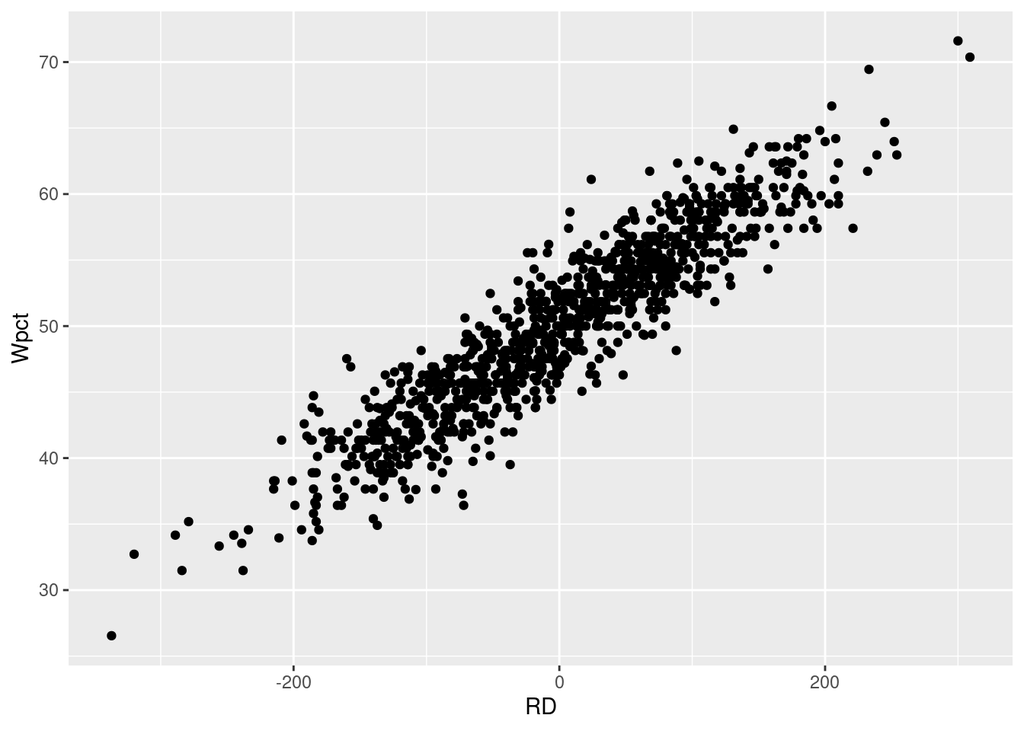

```r
teams2 %>% ggplot(aes(x=RD, y=Wpct)) +
    geom_point()
```

Run differential should be used to predict win percentage. Yes, the plot supports my intuition because the less run differential on team has, the less win percentage it has.

**Question 4**

Use the non-Tidymodels syntax to build a linear regression model to predict “Wpct” with “RD”. Comment on the quality of the resulting model. Include a brief examination of residuals in your commentary on model quality.

```r
model1 <- lm(Wpct ~ RD, data = teams2)
model1
```

```
Call:
lm(formula = Wpct ~ RD, data = teams2)

Coefficients:
(Intercept)           RD
   49.99806      0.06411
```

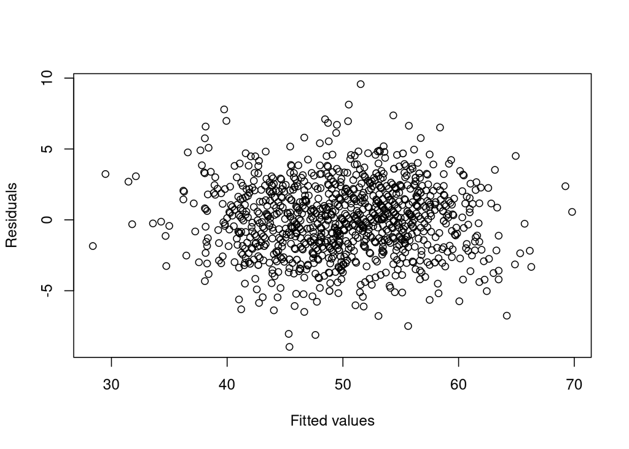

```r
res <- residuals(model1)
plot(fitted(model1), res, xlab = "Fitted values", ylab = "Residuals")
```

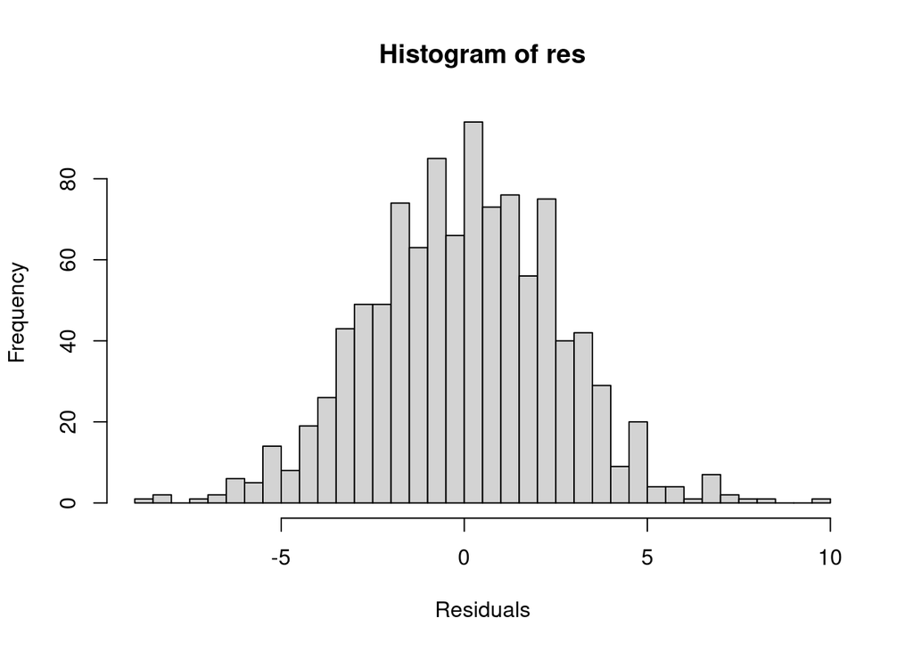

```r
hist(res, breaks = 50, xlab = "Residuals", ylab = "Frequency")
```

The quality of the model is quite good, as we can see in the histogram the graph has a normal distribution. It can certanly be better, but it is a model which we can work with.

**Question 5**

Repeat Question 4 using the Tidymodels syntax.

```r
ames_recipe = recipe(Wpct ~ RD, data = teams2) %>%
  step_dummy(all_nominal()) #ensures that the model treats categorical variables properly

lm_model =
  linear_reg() %>% #model type for linear regression
  set_engine("lm") #engine for typical linear regression model

#link the model and recipe together into a workflow
lm_wflow =
  workflow() %>%
  add_model(lm_model) %>%
  add_recipe(ames_recipe)

lm_fit = fit(lm_wflow, teams2)

lm_fit
```

```
══ Workflow [trained] ══════════════════════════════════════════════════════════
Preprocessor: Recipe
Model: linear_reg()

── Preprocessor ────────────────────────────────────────────────────────────────
1 Recipe Step

• step_dummy()

── Model ───────────────────────────────────────────────────────────────────────

Call:
stats::lm(formula = ..y ~ ., data = data)

Coefficients:
(Intercept)           RD
   49.99806      0.06411
```

```r
glance(lm_fit)
```

```
# A tibble: 1 × 12
  r.squared adj.r.squared sigma statistic p.value    df logLik   AIC   BIC
      <dbl>         <dbl> <dbl>     <dbl>   <dbl> <dbl>  <dbl> <dbl> <dbl>
1     0.859         0.859  2.56     6385.       0     1 -2472. 4951. 4965.
# ℹ 3 more variables: deviance <dbl>, df.residual <int>, nobs <int>
```

Before proceeding to the next questions, read-in the “churn.csv” file into a dataframe called “churn”.

```r
churn <- read.csv("churn.csv")
str(churn)
```

```
'data.frame':   7043 obs. of  13 variables:
 $ gender          : chr  "Female" "Male" "Male" "Male" ...
 $ Partner         : chr  "Yes" "No" "No" "No" ...
 $ Dependents      : chr  "No" "No" "No" "No" ...
 $ tenure          : int  1 34 2 45 2 8 22 10 28 62 ...
 $ PhoneService    : chr  "No" "Yes" "Yes" "No" ...
 $ MultipleLines   : chr  "No phone service" "No" "No" "No phone service" ...
 $ InternetService : chr  "DSL" "DSL" "DSL" "DSL" ...
 $ OneMoreService  : chr  "Yes" "Yes" "Yes" "Yes" ...
 $ Contract        : chr  "Month-to-month" "One year" "Month-to-month" "One year" ...
 $ PaperlessBilling: chr  "Yes" "No" "Yes" "No" ...
 $ PaymentMethod   : chr  "Electronic check" "Mailed check" "Mailed check" "Bank transfer (automatic)" ...
 $ MonthlyCharges  : num  29.9 57 53.9 42.3 70.7 ...
 $ Churn           : chr  "No" "No" "Yes" "No" ...
```

Convert all of the character variables to factors as these are categorical.

```r
churn = churn %>% mutate(Partner = as_factor(Partner)) %>%
  mutate(gender = as_factor(gender)) %>%
  mutate(Dependents = as_factor(Dependents)) %>%
  mutate(PhoneService = as_factor(PhoneService)) %>%
  mutate(MultipleLines = as_factor(MultipleLines)) %>%
  mutate(InternetService = as_factor(InternetService)) %>%
  mutate(OneMoreService = as_factor(OneMoreService))  %>%
  mutate(PaperlessBilling = as_factor(PaperlessBilling)) %>%
  mutate(PaymentMethod = as_factor(PaymentMethod)) %>%
  mutate(Churn = as_factor(Churn)) %>%
  mutate(Contract = as_factor(Contract))
str(churn)
```

```
'data.frame':   7043 obs. of  13 variables:
 $ gender          : Factor w/ 2 levels "Female","Male": 1 2 2 2 1 1 2 1 1 2 ...
 $ Partner         : Factor w/ 2 levels "Yes","No": 1 2 2 2 2 2 2 2 1 2 ...
 $ Dependents      : Factor w/ 2 levels "No","Yes": 1 1 1 1 1 1 2 1 1 2 ...
 $ tenure          : int  1 34 2 45 2 8 22 10 28 62 ...
 $ PhoneService    : Factor w/ 2 levels "No","Yes": 1 2 2 1 2 2 2 1 2 2 ...
 $ MultipleLines   : Factor w/ 3 levels "No phone service",..: 1 2 2 1 2 3 3 1 3 2 ...
 $ InternetService : Factor w/ 3 levels "DSL","Fiber optic",..: 1 1 1 1 2 2 2 1 2 1 ...
 $ OneMoreService  : Factor w/ 2 levels "Yes","No": 1 1 1 1 1 1 1 1 1 1 ...
 $ Contract        : Factor w/ 3 levels "Month-to-month",..: 1 2 1 2 1 1 1 1 1 2 ...
 $ PaperlessBilling: Factor w/ 2 levels "Yes","No": 1 2 1 2 1 1 1 2 1 2 ...
 $ PaymentMethod   : Factor w/ 4 levels "Electronic check",..: 1 2 2 3 1 1 4 2 1 3 ...
 $ MonthlyCharges  : num  29.9 57 53.9 42.3 70.7 ...
 $ Churn           : Factor w/ 2 levels "No","Yes": 1 1 2 1 2 2 1 1 2 1 ...
```

No 1 Yes 2

**Question 6**

Split the datset into training and testing sets. Put 70% of the data in the training set. Stratify the split by the response variable “Churn”. Use a random number seed of 1234.

```r
set.seed(1234)
churn_split = initial_split(churn, prop = 0.7, strata = Churn)
train = training(churn_split)
test = testing(churn_split)
```

How many rows are in the training and testing datasets after you build the split?

```r
nrow(train)
```

```
[1] 4929
```

```r
nrow(test)
```

```
[1] 2114
```

The training set has 4929 rows and the test has 2114

**Question 7**

Examine the “Churn” variable in the training dataset. This is our response variable and indicates if a customer left the company or not. What happens to the majority of customers in this dataset? What would our accuracy be if we assumed that what happened to the majority happened to everyone? Recall, that we call this quantity the “naive accuracy”.

```r
yes = filter(train, Churn == "Yes")
no = filter(train, Churn == "No")
nrow(yes)/nrow(train)
```

```
[1] 0.2653682
```

```r
nrow(no)/nrow(train)
```

```
[1] 0.7346318
```

**Question 8**

Build a logistic regression model with “MonthlyCharges” to predict “Churn”. Comment on this model.

```r
logreg_model = #give the model type a name
  logistic_reg() %>% #specify that we are doing logistic regression
  set_engine("glm") #specify the specify type of linear tool we want to use

logreg_recipe = recipe(Churn ~ MonthlyCharges , data = train)

logreg_wf = workflow() %>%
  add_recipe(logreg_recipe) %>%
  add_model(logreg_model)

logreg_fit = fit(logreg_wf,train)

options(scipen = 999)
tidy(logreg_fit)
```

```
# A tibble: 2 × 5
  term           estimate std.error statistic   p.value
  <chr>             <dbl>     <dbl>     <dbl>     <dbl>
1 (Intercept)     -1.99     0.0874      -22.8 3.57e-115
2 MonthlyCharges   0.0144   0.00114      12.6 2.51e- 36
```

```r
glance(logreg_fit)
```

```
# A tibble: 1 × 8
  null.deviance df.null logLik   AIC   BIC deviance df.residual  nobs
          <dbl>   <int>  <dbl> <dbl> <dbl>    <dbl>       <int> <int>
1         5704.    4928 -2768. 5540. 5553.    5536.        4927  4929
```

```r
predictions = predict(logreg_fit, train, type="prob") #develop predicted probabilities
head(predictions) #shows the first six rows of predictions
```

```
# A tibble: 6 × 2
  .pred_No .pred_Yes
     <dbl>     <dbl>
1    0.827     0.173
2    0.764     0.236
3    0.800     0.200
4    0.671     0.329
5    0.827     0.173
6    0.782     0.218
```

According to the model the bigger the Monthly Charges then there is more probability for the customer to left the company. The p-value is significant so we could say that this is a good model.

**Question 9**

Build a logistic regression model with “MonthlyCharges” and the “OneMoreService” variable (this variable indicates if customers are paying for any add-on services.

```r
logreg_model2 = #give the model type a name
  logistic_reg() %>% #specify that we are doing logistic regression
  set_engine("glm") #specify the specify type of linear tool we want to use

logreg_recipe2 = recipe(Churn ~ MonthlyCharges + OneMoreService, data = train)

logreg_wf2 = workflow() %>%
  add_recipe(logreg_recipe2) %>%
  add_model(logreg_model2)

logreg_fit2 = fit(logreg_wf2,train)
```

```r
options(scipen = 999)
tidy(logreg_fit2)
```

```
# A tibble: 3 × 5
  term             estimate std.error statistic  p.value
  <chr>               <dbl>     <dbl>     <dbl>    <dbl>
1 (Intercept)       -2.03     0.132     -15.3   3.56e-53
2 MonthlyCharges     0.0148   0.00156     9.48  2.56e-21
3 OneMoreServiceNo   0.0416   0.108       0.386 6.99e- 1
```

```r
glance(logreg_fit2)
```

```
# A tibble: 1 × 8
  null.deviance df.null logLik   AIC   BIC deviance df.residual  nobs
          <dbl>   <int>  <dbl> <dbl> <dbl>    <dbl>       <int> <int>
1         5704.    4928 -2768. 5541. 5561.    5535.        4926  4929
```

One More Service is not a good variable to include into the model. Its p-value is pretty bad and the overall AIC is bigger than the first one. This means that the first model is better than this second one.

**Question 10**

Build a classification tree on the training set using all of the variables.

```r
tree_recipe = recipe(Churn ~ MonthlyCharges + OneMoreService + gender + Partner + Dependents + tenure + PhoneService + MultipleLines + InternetService + OneMoreService + Contract + PaperlessBilling + PaymentMethod + MonthlyCharges, train)

tree_model = decision_tree() %>%
  set_engine("rpart", model = TRUE) %>% #don't forget the model = TRUE flag
  set_mode("classification")

tree_wflow =
  workflow() %>%
  add_model(tree_model) %>%
  add_recipe(tree_recipe)

tree_fit = fit(tree_wflow, train)
```

```r
#look at the tree's fit
tree_fit %>%
  extract_fit_parsnip() %>%
  pluck("fit")
```

```
n= 4929

node), split, n, loss, yval, (yprob)
      * denotes terminal node

 1) root 4929 1308 No (0.73463177 0.26536823)
   2) Contract=One year,Two year 2184  142 No (0.93498168 0.06501832) *
   3) Contract=Month-to-month 2745 1166 No (0.57522769 0.42477231)
     6) InternetService=DSL,No 1242  359 No (0.71095008 0.28904992) *
     7) InternetService=Fiber optic 1503  696 Yes (0.46307385 0.53692615)
      14) tenure>=17.5 724  289 No (0.60082873 0.39917127) *
      15) tenure< 17.5 779  261 Yes (0.33504493 0.66495507) *
```

```r
#rpart.plot(tree)
```

**Question 11**

What is the accuracy of this tree on the training and testing sets?

```r
#first develop predictions on the training set
treepred = predict(tree_fit, train, type = "class")
confusionMatrix(treepred$.pred_class, train$Churn,positive = "Yes")
```

```
Confusion Matrix and Statistics

          Reference
Prediction   No  Yes
       No  3360  790
       Yes  261  518

               Accuracy : 0.7868
                 95% CI : (0.7751, 0.7981)
    No Information Rate : 0.7346
    P-Value [Acc > NIR] : < 0.00000000000000022

                  Kappa : 0.372

 Mcnemar's Test P-Value : < 0.00000000000000022

            Sensitivity : 0.3960
            Specificity : 0.9279
         Pos Pred Value : 0.6650
         Neg Pred Value : 0.8096
             Prevalence : 0.2654
         Detection Rate : 0.1051
   Detection Prevalence : 0.1580
      Balanced Accuracy : 0.6620

       'Positive' Class : Yes
```

**End of Exam**